# **Project - Classification and Hypothesis Testing: Hotel Booking Cancellation Prediction**

#### **Question 6.5: What are some important features based on the tuned decision tree? (1 Mark)**

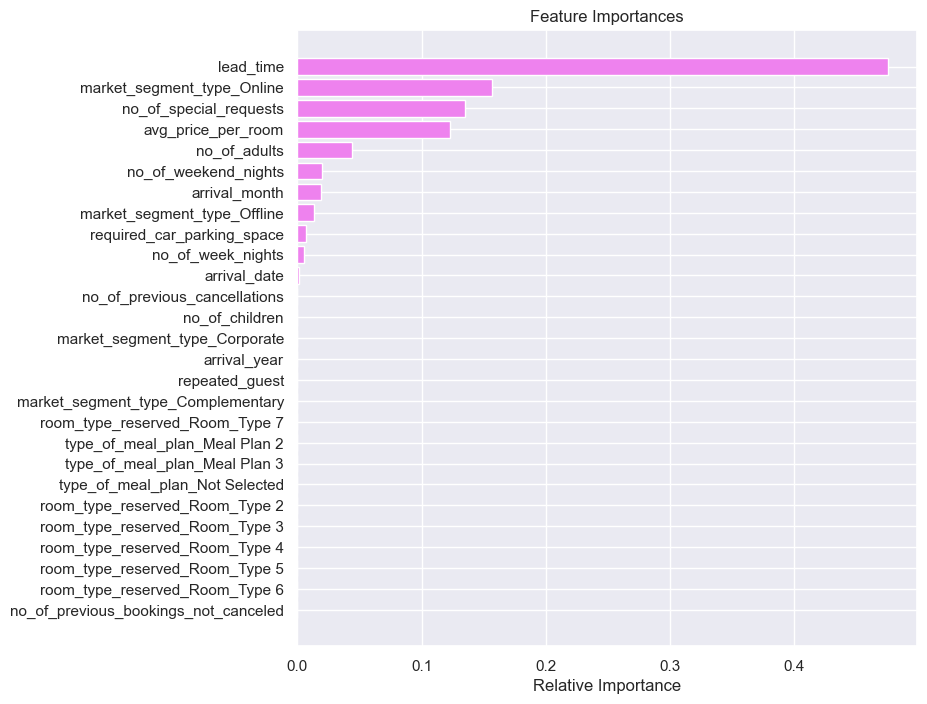

```python
# Remove _________ and complete the code

# Importance of features in the tree building

importances = estimator.feature_importances_
indices = np.argsort(importances)

plt.figure(figsize=(8, 8))
plt.title("Feature Importances")
plt.barh(range(len(indices)), importances[indices], color="violet", align="center")
plt.yticks(range(len(indices)), [feature_names[i] for i in indices])
plt.xlabel("Relative Importance")
plt.show()
```

**Write your answers here:** Lead time is the most important feature, followed by Online Market segment, number of special requests, average price of room and number of adults.

### **Question 7: Random Forest (4 Marks)**

#### **Question 7.1: Build a Random Forest Model (1 Mark)**

```python
# Remove _________ and complete the code

rf_estimator = RandomForestClassifier( random_state = 1)


rf_estimator.fit(X_train, y_train)
```

```
RandomForestClassifier(random_state=1)
```

#### **Question 7.2: Check the performance of the model on the train and test data (2 Marks)**

```
              precision    recall  f1-score   support

           0       0.99      1.00      1.00     17073
           1       1.00      0.99      0.99      8319

    accuracy                           0.99     25392
   macro avg       0.99      0.99      0.99     25392
weighted avg       0.99      0.99      0.99     25392
```

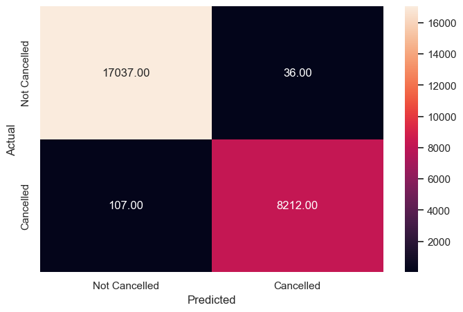

```python
# Remove _________ and complete the code

y_pred_train_rf = rf_estimator.predict(X_train)

metrics_score(y_train, y_pred_train_rf)
```

**Write your answers here:** For all the metrics in the training dataset, the Random Forest gives 99% to 100% score.

```
              precision    recall  f1-score   support

           0       0.91      0.95      0.93      7317
           1       0.88      0.80      0.84      3566

    accuracy                           0.90     10883
   macro avg       0.90      0.88      0.88     10883
weighted avg       0.90      0.90      0.90     10883
```

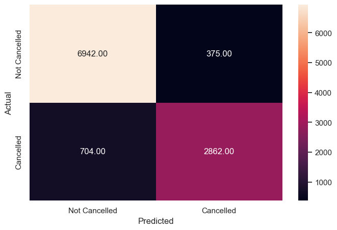

```python
# Remove _________ and complete the code

y_pred_test_rf = rf_estimator.predict(X_test)

metrics_score(y_test, y_pred_test_rf)
```

**Write your answers here:** The Random Forest classifier seems to be overfitting the training data. The recall on the training data is 0.99, while the recall on the test data is only ~ 0.80 for class 1

#### **Question 7.3: What are some important features based on the Random Forest? (1 Mark)**

Let's check the feature importance of the Random Forest

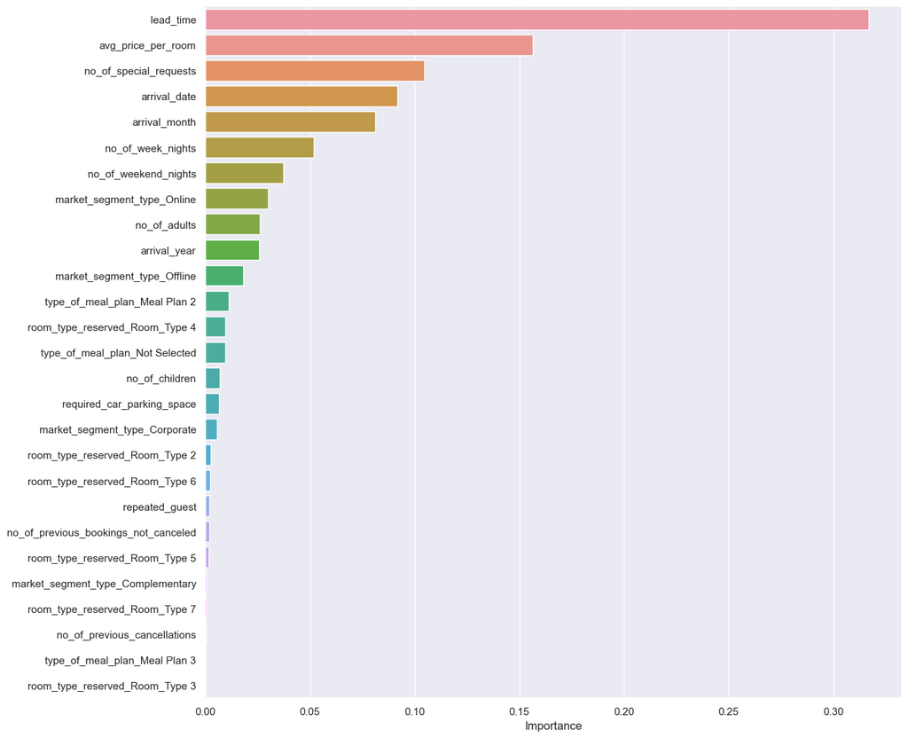

```python
# Remove _________ and complete the code

importances = rf_estimator.feature_importances_

columns = X.columns

importance_df = pd.DataFrame(importances, index = columns, columns = ['Importance']).sort_values(by = 'Importance', ascending = False)

plt.figure(figsize = (13, 13))

sns.barplot(importance_df.Importance, importance_df.index)
```

**Write your answers here:** The most important features are Lead time,average price per room, number of special requests, arrival date and arrival month.

### **Question 8: Conclude ANY FOUR key takeaways for business recommendations (4 Marks)**

**Write your answers here:**

Random forest verifies the results from the decision tree that the lead time is the most important feature for determining if a customer would cancel. the customers who booked a long time before their arrival date are most likely to cancel. The hotel should contact such customers about a week before the due date to confirm.

Corporate customers are the least likely to cancel. The hotel should target corporate customers more with advertisements.

Repeated customers are less likely to cancel. The hotel must focus advertisement on repeat customers.

The model and the data suggest that average price per room is an important factor for cancellation. The hotel should reduce the prices of the room on the months the hotel is least occupied to reduce cancellations by customers.